红葡萄酒质量数据探索 by 周鉴

========================================================

## 概述

本文将对提供的红葡萄酒质量数据进行探索分析。在分析的主要部分，将尝试得出哪个化学成分对葡萄酒质量的影响最大，并能做到根据给定的化学成分推断葡萄酒质量。最后是对分析探索过程的反思。

## 单变量图表

我们的数据集共有1599项数据，13项变量,其中与化学成分相关的变量有11个，quality为最终的输出变量，变量X只是编号，对本次分析不起实际作用，已经移除。

首先对数据进行一下总览:

```
##  fixed.acidity   volatile.acidity  citric.acid    residual.sugar
##  Min.   : 4.60   Min.   :0.1200   Min.   :0.000   Min.   : 0.900
##  1st Qu.: 7.10   1st Qu.:0.3900   1st Qu.:0.090   1st Qu.: 1.900
##  Median : 7.90   Median :0.5200   Median :0.260   Median : 2.200
##  Mean   : 8.32   Mean   :0.5278   Mean   :0.271   Mean   : 2.539
##  3rd Qu.: 9.20   3rd Qu.:0.6400   3rd Qu.:0.420   3rd Qu.: 2.600
##  Max.   :15.90   Max.   :1.5800   Max.   :1.000   Max.   :15.500
##    chlorides       free.sulfur.dioxide total.sulfur.dioxide
##  Min.   :0.01200   Min.   : 1.00       Min.   :  6.00
##  1st Qu.:0.07000   1st Qu.: 7.00       1st Qu.: 22.00
##  Median :0.07900   Median :14.00       Median : 38.00
##  Mean   :0.08747   Mean   :15.87       Mean   : 46.47
##  3rd Qu.:0.09000   3rd Qu.:21.00       3rd Qu.: 62.00
##  Max.   :0.61100   Max.   :72.00       Max.   :289.00
##     density             pH          sulphates         alcohol
##  Min.   :0.9901   Min.   :2.740   Min.   :0.3300   Min.   : 8.40
##  1st Qu.:0.9956   1st Qu.:3.210   1st Qu.:0.5500   1st Qu.: 9.50
##  Median :0.9968   Median :3.310   Median :0.6200   Median :10.20
##  Mean   :0.9967   Mean   :3.311   Mean   :0.6581   Mean   :10.42
##  3rd Qu.:0.9978   3rd Qu.:3.400   3rd Qu.:0.7300   3rd Qu.:11.10
##  Max.   :1.0037   Max.   :4.010   Max.   :2.0000   Max.   :14.90
##     quality
##  Min.   :3.000
##  1st Qu.:5.000
##  Median :6.000
##  Mean   :5.636
##  3rd Qu.:6.000
##  Max.   :8.000
```

通过数据总览，可以发现数据集中的变量都是连续的数值类型，其中quality为最终输出的质量评分。

下面对各个变量进行逐一单项探索。

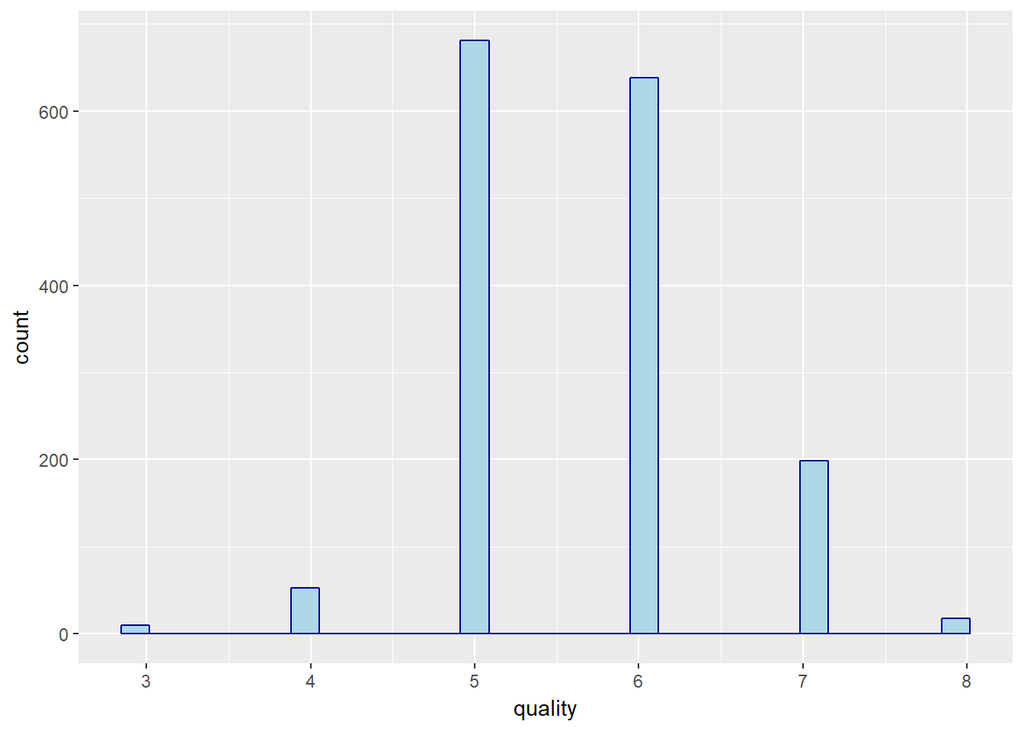

接下来我们对化学成分分别进行一下探索。因为都是数值类型，我们可以放在一起对比：

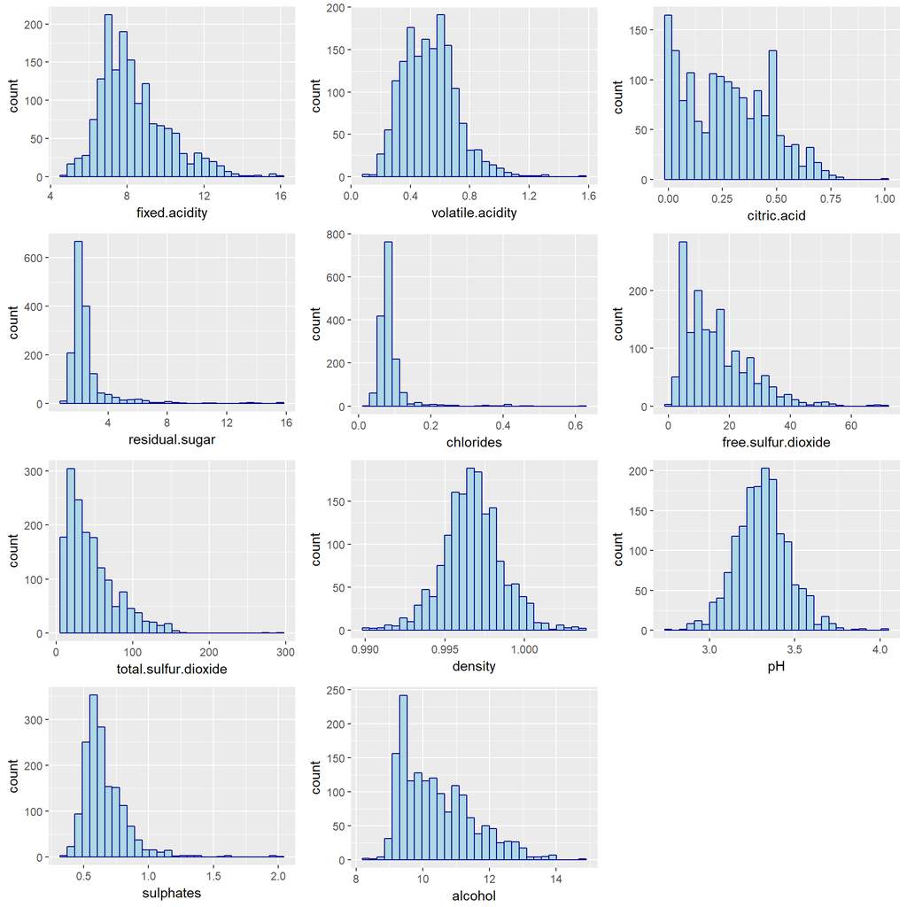

这些图形中还有两个比较极端的变量，residual.sugar和chlorids。它们的分布较为集中，导致图形不够均匀，这里采用数据变换的方式重新展现：

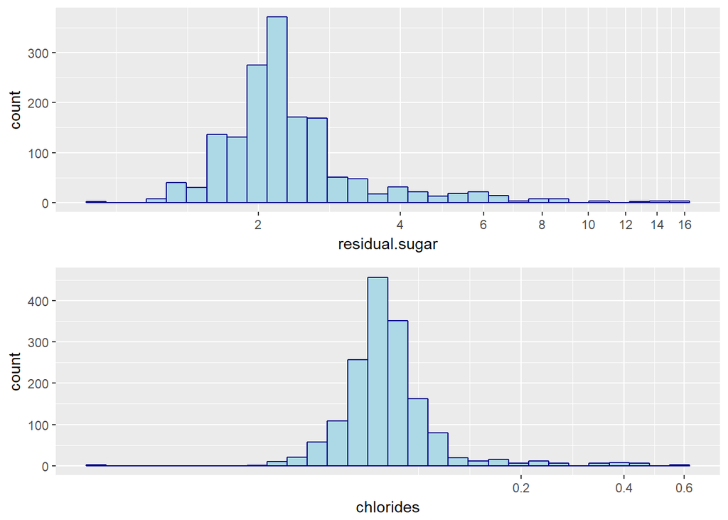

经过变换的图形能够更清晰的展示分布情况。

看完了总体分布情况，接下来我们进一步考察一下各个变量中的异常值。

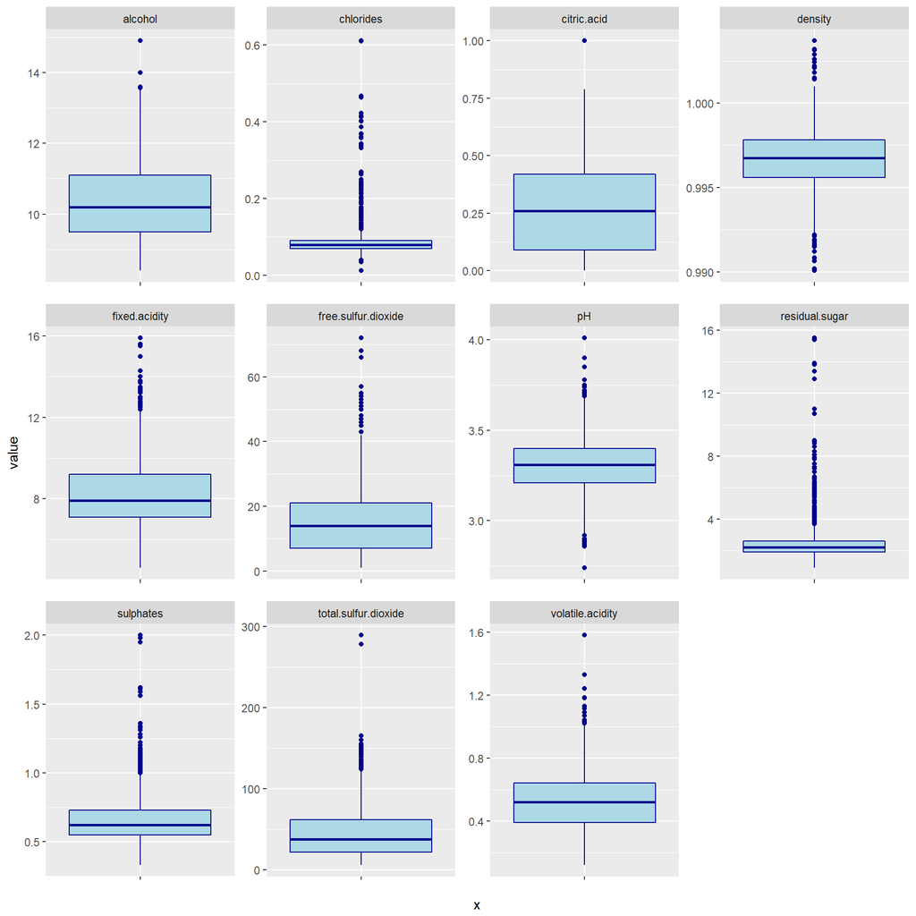

从箱线图中，我们可以看到每个变量都存在数量不等的离群点。观察这些离群点的具体值，我认为它们都在各自变量的合理取值范围之内，不存在数量级上的差异，因此可以认为这些离群点不是错误数据，属于正常数据中的离群点。再结合分布图形，我认为某些变量的大部分离群点其实是因为分布特征而被认定为离群点的。例如chlorides和residual.sugar，因为分布比较集中，因此一些稍稍偏离四分位区间的值虽然被划为离群点，但其实可以作为正常值用于我们的分析。排除了这些点之后，我认为剩余的个别离群点也可以保留下来，这些值在现实中的存在也是合理的，我们不应该过于“净化”我们的样本。

## 单变量分析

### 感兴趣的数据

- 首先从名字上看，我认为名字中带“酸”、“糖”的，会影响酒的口感，都与最终的评分结果quality有关；
- 名字中带“酸”的成分，应该会影响到酒的pH值；进而pH值或许也与quality相关；

### 新变量

为quality增加了一个离散型的变量quality_fac。

### 数据变换

为了更清晰的观察chlorides和residual.sugar的分布，对它们进行了取log10的变换。

## 双变量图表

在单变量探索阶段，我已经对若干对变量之间的关系有所预期。不过首先我们还是总览一下全体变量之间的散点图和相关度。

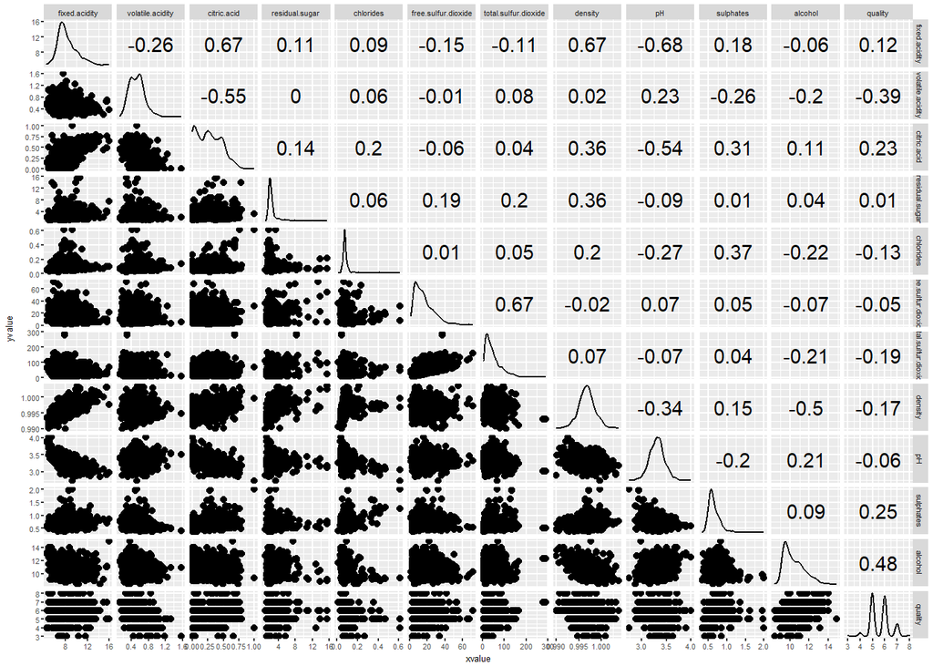

下面逐一查看一下我认为与quality相关度较高的，名字里带“酸”和“糖”的变量。

fixed.acidity:

```r
cor(x=wine_data$fixed.acidity,y=wine_data$quality)
```

```
## [1] 0.1240516
```

可以说存在正向的弱相关。

volatile.acidity:

```r
cor(x=wine_data$volatile.acidity,y=wine_data$quality)
```

```
## [1] -0.3905578
```

存在中等程度的负相关性。

citric.acid:

```r
cor(x=wine_data$citric.acid,y=wine_data$quality)
```

```
## [1] 0.2263725
```

也是较弱的正相关性。

residual.sugar:

```r
cor(x=wine_data$residual.sugar,y=wine_data$quality)
```

```
## [1] 0.01373164
```

出乎意料！可以说不存在相关性。

接下来我们再来观察一下这4个变量和quality的散点图/箱线图，更直观的感受一下它们在相关度上的差别。

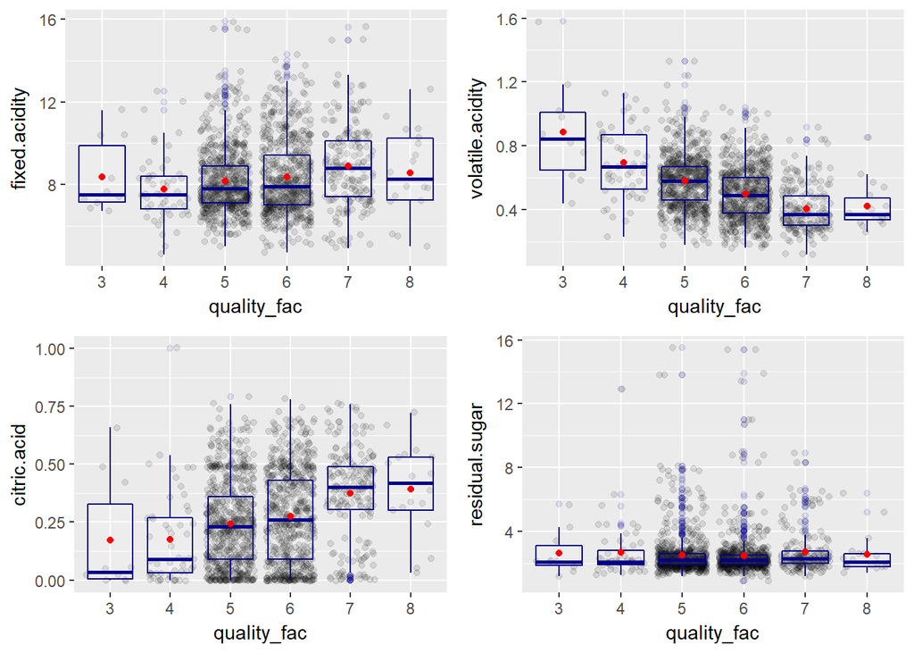

这四幅图的对比能很明显看出，3个“酸”类指标与quality之间存在一定的线性关系，而residual.sugar则非常不明显。这与我们上面计算相关度得出的结论一致。

我在之前还推测了3个“酸”指标和pH值之间的相关性，这里先直接通过图形来观察：

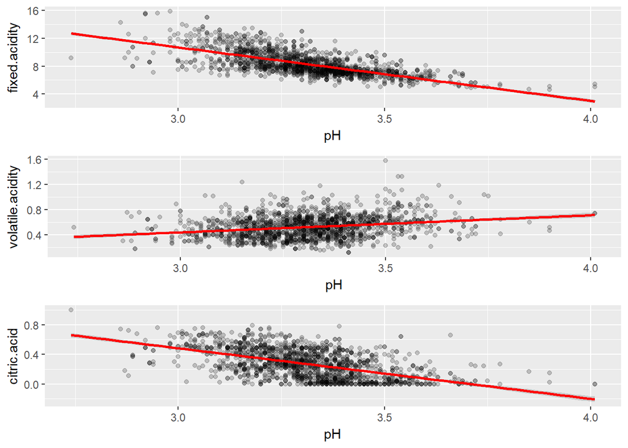

从图形来看这些数据间是存在一定的线性关系的，下面我们再计算它们的相关度。

```r
cor_faph <- cor(wine_data$fixed.acidity,wine_data$pH)
cor_faph
```

```
## [1] -0.6829782
```

```r
cor_vaph <- cor(wine_data$volatile.acidity,wine_data$pH)
cor_vaph
```

```
## [1] 0.2349373
```

```r
cor_caph <- cor(wine_data$citric.acid,wine_data$pH)
cor_caph
```

```
## [1] -0.5419041
```

可以看到计算的相关度结果与我们的图形所展示的是相匹配的，但volatile.acidity与pH竟然是正相关，也就是说volatile.acidity含量越高，酒的酸性越低，这与我们的常识有所背离。

## 双变量分析

在双变量图形的探索中，我首先对我之前所作的”酸和糖成分影响评分“假设进行了验证。从数据上看，fixed.acidity和citric.acid与评分之间是较弱的正相关，residual.sugar与quality可以说不相关，仅有volatile.acidity与quality存在中等程度的负相关。我认为我这个假设是不成立的。

接下来对另外一个假设，”酸成分影响pH值“，进行了验证。结果中有两种酸成分与pH值存在较强的负相关，这印证了我们的假设。但volatile.acidity与pH存在较弱的正相关，这点如何解释还有待更专业的研究。

在全部数据中，观察到的最强的相关性就是fixed.acidity和pH之间的负相关，相关度-0.68。

## 多元图表

我们在双变量分析得到的结果中可以提取出这样两条信息: * fixed.acidity、citric.acid与quality存在较弱的正相关性。 * fixed.acidity、citric.acid与pH存在较强的负相关性。 接下来我们用多元图表来探索一下它们的共同作用下呈现出的相关性。

首先来看quality:

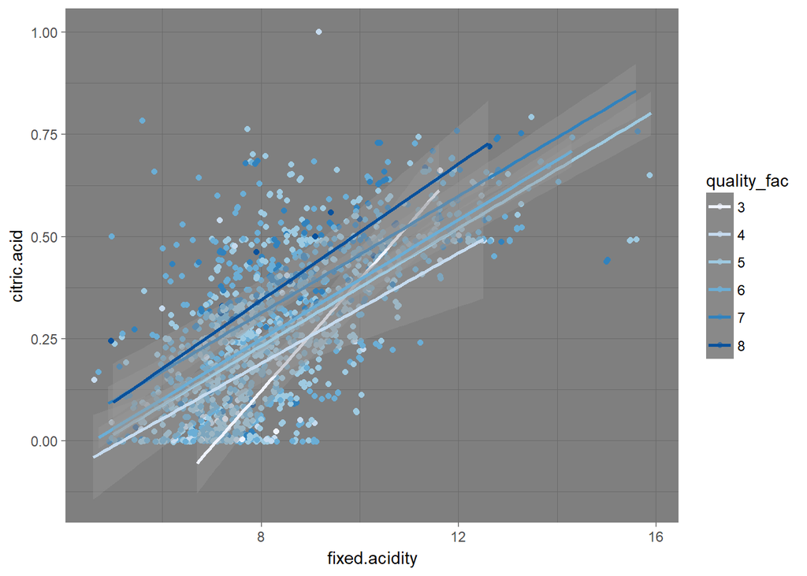

可以看出图形具有一定的层次。在fixed.acidity一定的情况下，citric.acid越高，最终评分也就越高。

接下来观察pH的图形特点:

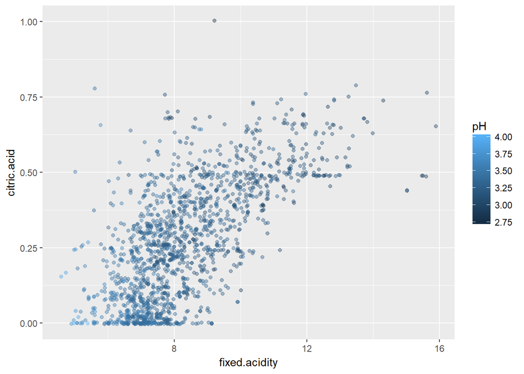

这里所呈现出的图形结果，但也体现了一种趋势和集中，但分层就不够明显。总体上可以说当citric.acid一定时，fixed.acidity越低的数据，pH值越高。

## 多元分析

我建立了两个多元图标来分别考查了fixed.acidity、citric.acid与quality的相关性和fixed.acidity、citric.acid与pH的相关性。接下来我想要更精确的回答最初的问题：哪个化学成分影响红葡萄酒的质量？

首先我要从相关度表格中选出与quality的相关度绝对值大于0.1的成分：

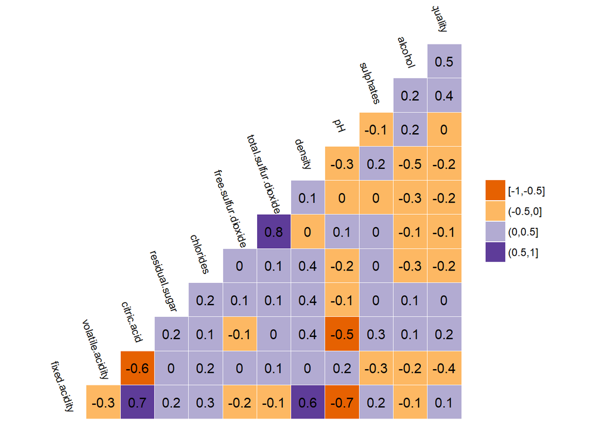

从图中看，也就是除了pH和residual.sigar之外的其他成分。具体计算一下发现有三个变量相关度绝对值低于0.1。

residual.sugar:

```r
cor(wine_data$residual.sugar,wine_data$quality)
```

```
## [1] 0.01373164
```

free.sulfur.dioxide:

```r
cor(wine_data$free.sulfur.dioxide,wine_data$quality)
```

```
## [1] -0.05065606
```

pH:

```r
cor(wine_data$pH,wine_data$quality)
```

```
## [1] -0.05773139
```

排除了这三样成分后，我们对剩余的变量和quality的关系进行线性回归分析：

```
##
## Calls:
## m1: lm(formula = quality ~ fixed.acidity, data = wine_data)
## m2: lm(formula = quality ~ fixed.acidity + volatile.acidity, data = wine_data)
## m3: lm(formula = quality ~ fixed.acidity + volatile.acidity + citric.acid,
##     data = wine_data)
## m4: lm(formula = quality ~ fixed.acidity + volatile.acidity + citric.acid +
##     chlorides, data = wine_data)
## m5: lm(formula = quality ~ fixed.acidity + volatile.acidity + citric.acid +
##     chlorides + total.sulfur.dioxide, data = wine_data)
## m6: lm(formula = quality ~ fixed.acidity + volatile.acidity + citric.acid +
##     chlorides + total.sulfur.dioxide + density, data = wine_data)
## m7: lm(formula = quality ~ fixed.acidity + volatile.acidity + citric.acid +
##     chlorides + total.sulfur.dioxide + density + sulphates, data = wine_data)
## m8: lm(formula = quality ~ fixed.acidity + volatile.acidity + citric.acid +
##     chlorides + total.sulfur.dioxide + density + sulphates +
##     alcohol, data = wine_data)
##
## ========================================================================================================================================
##                              m1            m2            m3            m4            m5            m6            m7            m8
## ----------------------------------------------------------------------------------------------------------------------------------------
##   (Intercept)               5.157***      6.451***      6.450***      6.553***      6.787***    136.978***    141.105***     28.165
##                            (0.098)       (0.121)       (0.121)       (0.122)       (0.125)      (13.426)      (12.975)      (15.083)
##   fixed.acidity             0.058***      0.012         0.014         0.007        -0.015         0.098***      0.097***      0.055**
##                            (0.012)       (0.011)       (0.015)       (0.015)       (0.015)       (0.018)       (0.018)       (0.017)
##   volatile.acidity                       -1.732***     -1.746***     -1.601***     -1.464***     -1.275***     -0.999***     -1.137***
##                                          (0.107)       (0.127)       (0.129)       (0.129)       (0.127)       (0.125)       (0.120)
##   citric.acid                                          -0.032         0.185         0.410**       0.253         0.157        -0.198
##                                                        (0.152)       (0.158)       (0.159)       (0.155)       (0.150)       (0.145)
##   chlorides                                                          -2.017***     -2.032***     -1.312**      -2.895***     -1.584***
##                                                                      (0.413)       (0.407)       (0.402)       (0.416)       (0.408)
##   total.sulfur.dioxide                                                             -0.004***     -0.003***     -0.003***     -0.002***
##                                                                                    (0.001)       (0.001)       (0.001)       (0.001)
##   density                                                                                      -131.730***   -136.652***    -25.583
##                                                                                                 (13.584)      (13.130)      (15.122)
##   sulphates                                                                                                     1.234***      0.916***
##                                                                                                                (0.115)       (0.112)
##   alcohol                                                                                                                     0.268***
##                                                                                                                              (0.021)
## ----------------------------------------------------------------------------------------------------------------------------------------
##   R-squared                 0.015         0.153         0.153         0.166         0.190         0.236         0.287         0.356
##   adj. R-squared            0.015         0.152         0.152         0.164         0.188         0.233         0.284         0.353
##   sigma                     0.802         0.744         0.744         0.739         0.728         0.707         0.683         0.650
##   F                        24.960       144.319        96.170        79.140        74.906        81.740        91.526       109.751
##   p                         0.000         0.000         0.000         0.000         0.000         0.000         0.000         0.000
##   Log-likelihood        -1914.235     -1793.729     -1793.707     -1781.805     -1757.813     -1711.930     -1656.090     -1575.112
##   Deviance               1026.127       882.555       882.530       869.490       843.784       796.723       742.976       671.409
##   AIC                    3834.471      3595.459      3597.415      3575.611      3529.625      3439.860      3330.180      3170.224
##   BIC                    3850.602      3616.968      3624.300      3607.874      3567.265      3482.877      3378.574      3223.995
##   N                      1599          1599          1599          1599          1599          1599          1599          1599
## ========================================================================================================================================
```

综合评估最后给出的指标，我认为m8的表现是最好的，因此采用m8作为线性回归的公式，最终结果为: $quality = 28.165 + 0.055\times fixed.acidity - 1.137\times volatile.acidity - 0.198\times citric.acid - 1.584\times chlorides - 0.002\times total.sulfur.dioxide -25.583\times density + 0.916\times sulphates + 0.268\times alcohol$

## 最终图表

### Plot One

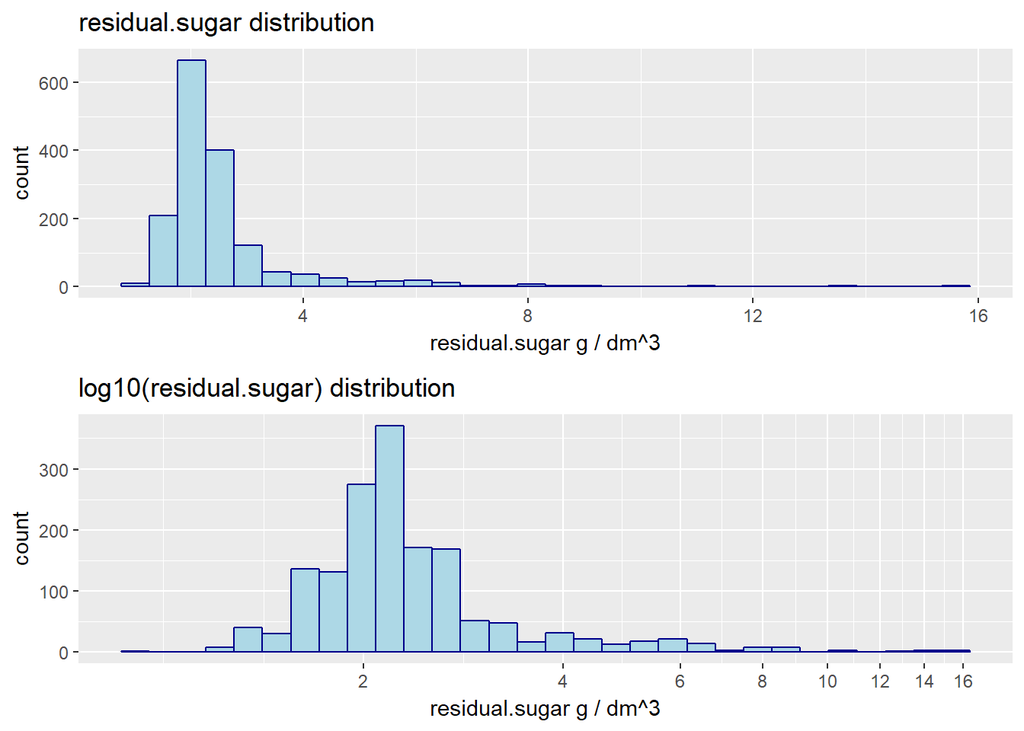

### Description One

我们在一元分析时发现residual.sugar变量的分布图形存在坐标中断的问题，影响可读性。与之类似的还有clorides。经过取log10变换之后，呈现的图形对分布情况的展示更加清晰。

### Plot Two

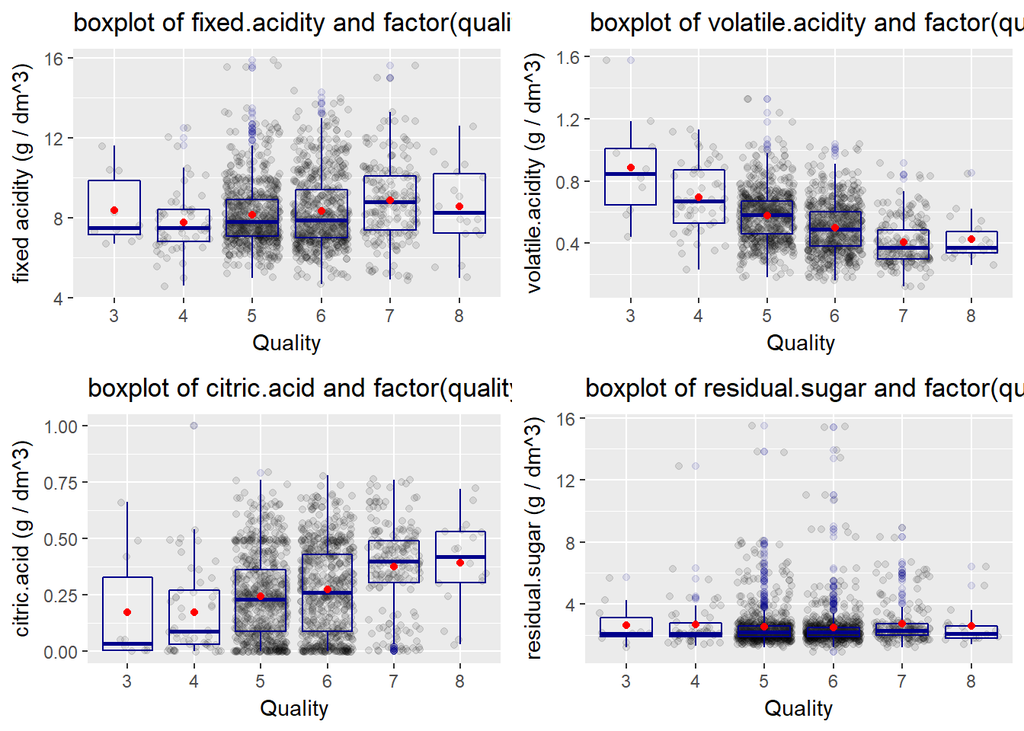

### Description Two

在分析变量与quality之间相关性时我采用了线框图 + 散点图的形式，这种形式首先能够展示变量在各个评分段的分布情况，其次展示了它们与quality的相关性。通过图中的对比能很明显看出fixed.acidity和citric.acid与quality的正相关性，volatile.acidity的负相关性，以及residual.sugar的低关联性。

### Plot Three

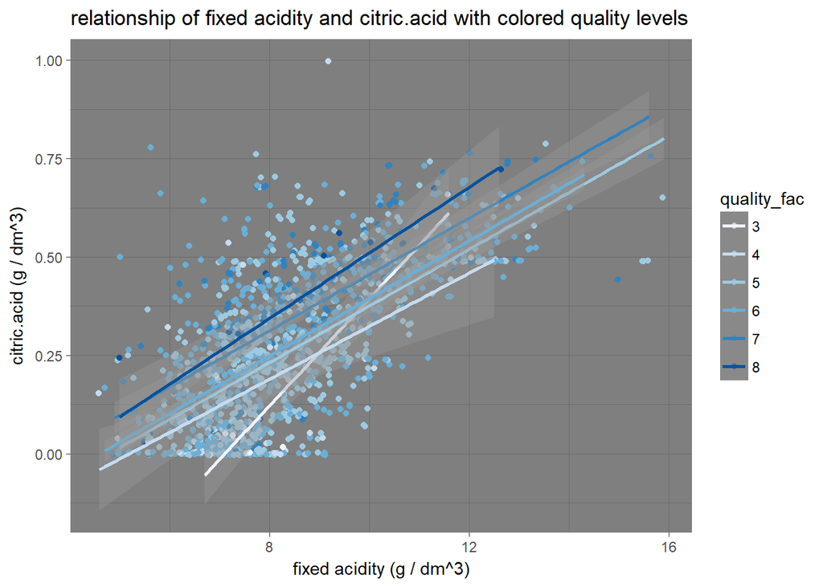

### Description Three

在多元关系部分我们使用了带有颜色的散点图来展示。这种方式不仅能展现出两个坐标轴上变量的关系，还能通过颜色集中的位置展现出quality与这两个变量间的关系。如图中所示，除了能通过位置的走势看出citric.acid与fixed.acidity之间的正相关性之外，我们还能清楚地看到不同颜色的点聚集形成的层次，从而得出只从这两个变量角度考查，更高的citric.acid的酒类质量更好的结论。

## 反思

- 本次分析所用到的数据集中，我认为没有出现错误数据，同时对于发现的离群点，我认为属于合理范围，保留有利于反应真实情况，也都没有采取措施进行处理。总的来说我认为这种行为还是有利的，可以防止我们的结果过度拟合，但也可能会产生偏差。
- 本次分析的数据的quality评分集中在3~8分，所以我认为得到的结果还是有一定局限性的，需要补全更多数据才对红葡萄酒总体有意义。但是因为这个评分是由三位专家人工进行评价的，因此或许真的不会出现超过这个范围的分数。
- 在线性回归模型的选择上，我只是单纯对比了mtable结果中的一些数据的大小。在最佳模型的选择上，是否有更系统的标准，进而更深入的学习线性回归的原理，是接下来想要进行的事情。